# Formatting and cleaning the genomic data

## 2.2 Missing data per individual

We then check the number of missing data per individual.

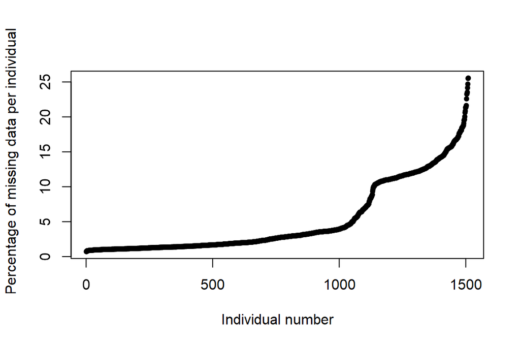

```r
tab <- df %>%
  column_to_rownames("snp") %>%
  as_tibble() %>%
  sapply(function(x) sum(is.na(x))*100/nrow(df)) %>%
  as.data.frame() %>%
  set_colnames(c("na_freq")) %>%
  rownames_to_column(var = "individual") %>%
  as_tibble() %>%
  arrange(na_freq) %>%
  mutate(id=1:nrow(.))

plot(tab$id,tab$na_freq,
     pch=20,
     xlab="Individual number",
     ylab="Percentage of missing data per individual")
```

Possible thresholds for the number of missing values per individual:

- 1495 individuals have less than 20% missing data
- 1478 individuals have less than 18% missing data
- 1422 have less than 15% missing data.

```r
# Specifying the chosen threshold:
threshold_NA_per_individual <- 18

# Removing individuals with more than 18% missing data
df <- df %>% dplyr::select(snp, tab[tab$na_freq<threshold_NA_per_individual,]$individual)
```

We keep the 1478 individuals that have less than 18% missing data.

# 3 Minor allele frequencies

We want to remove *minor allele frequencies* (MAF) for gene-environment association analyses, but not for population genetic structure estimation.

Therefore, we produce two datasets: one with MAF and the other without (i.e. we remove MAF < 1%), that we store in a list.

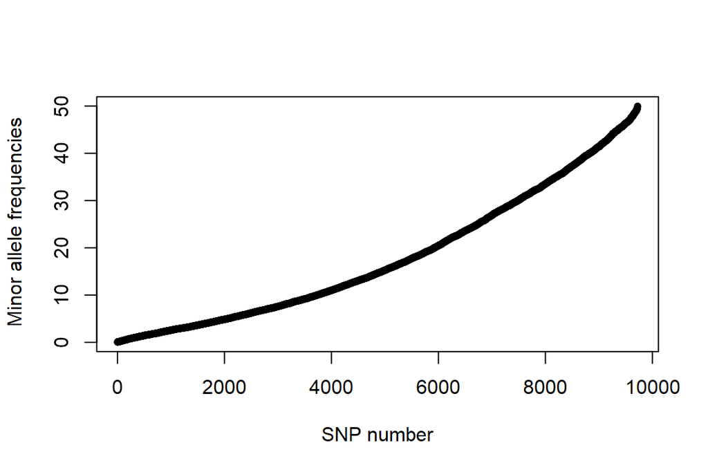

```r
tab <- df %>%
  column_to_rownames("snp") %>%
  t() %>%
  as_tibble() %>%
  sapply(function(x) sum(x,na.rm=T)*100/(2*nrow(.))) %>%
  as.data.frame() %>%
  set_colnames(c("MAF")) %>%
  rownames_to_column(var = "snp") %>%
  as_tibble() %>%
  arrange(MAF) %>%
  mutate(id=1:nrow(.))

plot(tab$id,tab$MAF,
     pch=20,
     xlab="SNP number",
     ylab="Minor allele frequencies")
```

```r
list_geno <- list(list_withmaf=list(df = df),
                  list_withoutmaf=list(df = df %>% filter(!snp %in% tab[tab$MAF<1,]$snp)))
```

In the dataset without MAF, we remove the 316 SNPs that have MAF < 1%: 9408 SNPs left.

# 4 Missing data per SNP

We then look at the number of missing data per SNPs:

```r
remove_NA_perSNP <- function(x){

tab <- x$df %>%
  column_to_rownames("snp") %>%
  t() %>%
  as_tibble() %>%
  sapply(function(x) sum(is.na(x))*100/nrow(.)) %>%
  as.data.frame() %>%
  set_colnames(c("na_freq")) %>%
  rownames_to_column(var = "snp") %>%
  as_tibble() %>%
  arrange(na_freq) %>%
  mutate(id=1:nrow(.))


df <- x$df %>% filter(snp %in% tab[tab$na_freq<20,]$snp)

list(df=df,tab=tab)
}

list_geno <- lapply(list_geno,remove_NA_perSNP)
```

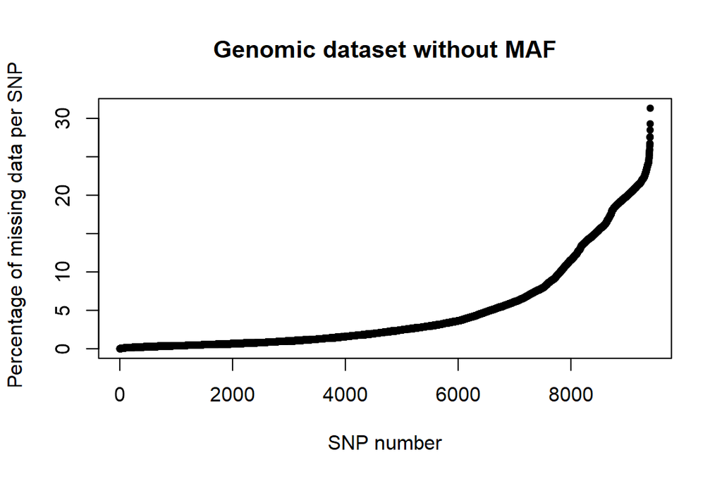

```r
plot(list_geno$list_withoutmaf$tab$id,list_geno$list_withoutmaf$tab$na_freq,
     pch=20,
     xlab="SNP number",
     ylab="Percentage of missing data per SNP",
     main="Genomic dataset without MAF")
```

In the dataset without MAF, 9009 SNPs have less than 20% missing data and 8431 have less than 15% missing data.

We keep SNPs with less than 20% missing data. So, the two datasets contain 1478 individuals and there are 9009 SNPs left in the dataset without MAF and 9320 in the dataset with MAF.

# 5 Exporting

## 5.1 Allele counts (i.e. 0/1/2)

```r
for(i in 1:length(list_geno)){
  specMAF <- names(list_geno[i])[1] %>% str_sub(6, -1)

  list_geno[[i]]$df %>%
    dplyr::select(snp,sort(colnames(.[,-1]))) %>% # sort columns (i.e. individuals) by alphabetical order
    write_csv(here(paste0("data/genomic_data/filtered_allele_counts_",specMAF,".csv")),
            append=FALSE)
}

# Reminder
# to download the dataset with snp_ID as first column: use `read.csv` with missing row.names
# to download the dataset with snp_ID as row names: use `read.csv` with row.names = 1
```

562881 missing data in the dataset with MAF, and 544887 missing data in the dataset without MAF.

## 5.2 Allele frequencies

```r
# Only useful for the dataset without MAF

compute_allele_freq <- function(x){

x %>%
  t() %>%
  as.data.frame() %>%
  rownames_to_column(var="pop") %>%
  mutate(pop=str_sub(pop,1,3)) %>%
  group_by(pop) %>%
  summarise_all(~sum(., na.rm = TRUE)/((n()-sum(is.na(.)))*2))

}

df_freq <- list_geno$list_withoutmaf$df %>%
  column_to_rownames("snp") %>%
  compute_allele_freq()

df_freq %>%
  write_csv(here(paste0("data/genomic_data/filtered_allele_frequencies_withoutmaf.csv")),
            append=FALSE)

df_freq[1:10,1:8] %>%
  mutate(across(where(is.numeric), round, 2)) %>%
  kable_mydf(boldfirstcolumn = T, font_size = 12)
```

| pop | Affx-979041050 | Affx-979041051 | Affx-979041053 | Affx-979041054 | Affx-979041055 | Affx-979041057 | Affx-979041058 |
| --- | --- | --- | --- | --- | --- | --- | --- |
| ABA | 0.02 | 0.02 | 0.43 | 0.90 | 0.00 | 0.00 | 0.02 |
| ADE | 0.05 | 0.58 | 1.00 | 0.10 | 0.20 | 0.00 | 0.71 |
| AHI | 0.00 | 0.11 | 0.33 | 0.14 | 0.05 | 0.00 | 0.52 |
| ALT | 0.00 | 0.06 | 0.00 | 0.12 | 0.00 | 0.00 | 0.19 |
| ANI | 0.07 | 0.00 | 0.21 | 0.00 | 0.00 | 0.00 | 0.25 |
| ANO | 0.00 | 0.55 | 0.18 | 0.05 | 0.00 | 0.00 | 0.50 |
| ARM | 0.00 | 0.00 | 0.19 | 0.19 | 0.00 | 0.00 | 0.38 |
| ARN | 0.00 | 0.06 | 0.12 | 0.12 | 0.03 | 0.03 | 0.44 |
| BAV | 0.00 | 0.00 | 0.27 | 0.57 | 0.00 | 0.10 | 0.36 |
| BAY | 0.00 | 0.30 | 0.10 | 0.20 | 0.03 | 0.00 | 0.17 |

8166 missing data in this dataset.

# 6 Imputation of missing data

We have to impute missing values to run the gene-environment association analyses.

For that, we impute the missing values based on the most common alleles in the main gene pool of the individual.

```r
gp <- read_csv(here("data/genomic_data/K10_indiv_Juliette.csv"), show_col_types = FALSE) %>%
  arrange(Individual) %>%
  mutate(Individual = Individual %>% str_replace("MAUbis","MAB"))


gp <- gp %>% dplyr::select(contains("K")) %>%  apply(MARGIN=1, function(x){

 K_names <- gp %>%  dplyr::select(contains("K")) %>% names()

 tibble(K_max = max(x),
        K_main = K_names[which.max(x)])
}) %>%
  bind_rows() %>%
  bind_cols(gp,.)
```

```r
list_geno <- mclapply(list_geno, function(x){

df <-  x$df %>%
  column_to_rownames("snp") %>%
  t() %>%
  as.data.frame() %>%
  rownames_to_column("Individual") %>%
  left_join(gp[,c("Individual","K_main")],by="Individual") %>%
  dplyr::select(Individual,K_main,everything())

list(df=df)

})
```

```r
# We can check that the imputation worked fine

subset <- list_geno$list_withoutmaf$df[list_geno$list_withoutmaf$df$K_main=="K4",]
set.seed(12)
vec_snps_with_nas <- sample(colnames(subset)[colSums(is.na(subset)) > 0],10,replace=F) #extract some SNPs with NAs

subset_df <- lapply(vec_snps_with_nas, function(x){
  subset %>%
  tabyl(any_of(x)) %>%
  dplyr::select(1:2) %>%
  set_colnames(c("genotype","count")) %>%
  pivot_wider(names_from = "genotype", values_from = "count") %>%
  mutate(expected_value_after_imp=colnames(.)[which.max(across(everything(.)))],snp = x)
}) %>%
  bind_rows() %>%
  dplyr::rename(nb_0_bf_imp = `0`,
                nb_1_bf_imp = `1`,
                nb_2_bf_imp = `2`,
                nb_NA_bf_imp = `NA`)
```

We impute the missing values:

```r
# Replace NAs by (1) subseting by GP, (2) imputing NAs, (3) reassembling the GP.
list_geno <- mclapply(list_geno, function(x){

for(i in unique(x$df$K_main)){
  subset <- x$df[x$df$K_main==i,]
  subset <- apply(subset[,3:ncol(subset)], 2, function(x) replace(x, is.na(x), as.numeric(names(which.max(table(x))))))
  x$df[x$df$K_main==i,3:ncol(x$df)] <- subset
}

list(df=x$df)

})
```

For the imputation of missing values, another option would be to use the function `impute` of the `LEA` R package to do the imputation: it uses ancestry and genotype frequency information (estimated with the `snmf` function, which estimates admixture coefficients) to do the imputation.

We can check that the imputation worked well:

```r
# If we want to check that the imputation worked fine
  # Look at the SNPs that had NAs before imputation
subset <- list_geno$list_withoutmaf$df[list_geno$list_withoutmaf$df$K_main=="K4",]
subset_df_2 <- lapply(vec_snps_with_nas, function(x){
  subset %>%
  tabyl(any_of(x)) %>%
  dplyr::select(1:2) %>%
  set_colnames(c("genotype","count")) %>%
  pivot_wider(names_from = "genotype", values_from = "count") %>%
  mutate(snp = x)
}) %>%
  bind_rows() %>%
  dplyr::rename(nb_0_after_imp = `0`,
                nb_1_after_imp = `1`,
                nb_2_after_imp = `2`) %>%
  left_join(subset_df, by="snp") %>%
  dplyr::select(snp, contains("bf_imp"),expected_value_after_imp, everything())


subset_df_2  %>% kable_mydf(boldfirstcolumn = F, font_size = 11)
```

| snp | nb_0_bf_imp | nb_NA_bf_imp | nb_1_bf_imp | nb_2_bf_imp | expected_value_after_imp | nb_0_after_imp | nb_1_after_imp | nb_2_after_imp |
| --- | --- | --- | --- | --- | --- | --- | --- | --- |
| Affx-979087208 | 169 | 78 | NA | NA | 0 | 247 | NA | NA |
| Affx-979085666 | 233 | 7 | 7 | NA | 0 | 240 | 7 | NA |
| Affx-979085571 | 188 | 2 | 51 | 6 | 0 | 190 | 51 | 6 |
| Affx-979045045 | 106 | 1 | 111 | 29 | 1 | 106 | 112 | 29 |
| Affx-979063486 | 187 | 6 | 51 | 3 | 0 | 193 | 51 | 3 |
| Affx-979054708 | 59 | 59 | 104 | 25 | 1 | 59 | 163 | 25 |
| Affx-979072170 | 210 | 25 | 12 | NA | 0 | 235 | 12 | NA |
| Affx-979044492 | 147 | 2 | 91 | 7 | 0 | 149 | 91 | 7 |
| Affx-979045764 | 163 | 1 | 75 | 8 | 0 | 164 | 75 | 8 |
| Affx-979042896 | 68 | 1 | 110 | 68 | 1 | 68 | 111 | 68 |

The imputation worked well :)

```r
list_geno <- mclapply(list_geno, function(x){

x$df <- x$df %>%
  arrange(Individual) %>%
  column_to_rownames(var="Individual") %>%
  dplyr::select(-K_main) %>%
  t() %>%
  as.data.frame()

list(df=x$df)
})


# Visualization:
list_geno$list_withoutmaf$df[1:10,1:10]  %>% kable_mydf(boldfirstcolumn = T, font_size = 11)
```

|  | ABA01 | ABA02 | ABA03 | ABA04 | ABA05 | ABA06 | ABA07 | ABA08 | ABA09 | ABA10 |
| --- | --- | --- | --- | --- | --- | --- | --- | --- | --- | --- |
| Affx-979041050 | 0 | 1 | 0 | 0 | 0 | 0 | 0 | 0 | 0 | 0 |
| Affx-979041051 | 0 | 1 | 0 | 0 | 0 | 0 | 0 | 0 | 0 | 0 |
| Affx-979041053 | 1 | 1 | 0 | 0 | 1 | 0 | 0 | 1 | 2 | 2 |
| Affx-979041054 | 2 | 1 | 2 | 2 | 2 | 2 | 2 | 2 | 1 | 2 |
| Affx-979041055 | 0 | 0 | 0 | 0 | 0 | 0 | 0 | 0 | 0 | 0 |
| Affx-979041057 | 0 | 0 | 0 | 0 | 0 | 0 | 0 | 0 | 0 | 0 |
| Affx-979041058 | 0 | 1 | 0 | 0 | 0 | 0 | 0 | 0 | 0 | 0 |
| Affx-979041059 | 0 | 0 | 0 | 0 | 0 | 0 | 0 | 0 | 0 | 0 |
| Affx-979041060 | 0 | 0 | 0 | 0 | 0 | 0 | 0 | 0 | 0 | 0 |
| Affx-979041061 | 0 | 1 | 0 | 0 | 0 | 0 | 0 | 0 | 0 | 0 |

# 7 Exporting the genomic data

## 7.1 Individual-level allele counts

To run BayPass and LFMM, genomic data have to be allele counts at the individual level, so below we export the allele counts:

```r
for(i in 1:length(list_geno)){
  specMAF <- names(list_geno[i])[1] %>% str_sub(6, -1)

  list_geno[[i]]$df %>%
    rownames_to_column(var="snp_ID") %>%
    write_csv(here(paste0("data/genomic_data/imputed_allele_counts_",specMAF,".csv")),
            append=FALSE)
}
```

## 7.2 Population allele frequencies

To run the RDA and GF, the genomic data have to be population allele frequencies.

```r
# Calculate allele frequencies
list_geno <- mclapply(list_geno, function(x){

list(df=compute_allele_freq(x$df))

})


# export in csv
for(i in 1:length(list_geno)){
  specMAF <- names(list_geno[i])[1] %>% str_sub(6, -1)

  list_geno[[i]]$df %>%
  write_csv(here(paste0("data/genomic_data/imputed_allele_frequencies_",specMAF,".csv")),
            append=FALSE)
}



list_geno$list_withoutmaf$df[1:10,1:8]  %>%
  mutate(across(where(is.numeric), round, 2)) %>%
  kable_mydf(boldfirstcolumn = F, font_size = 11)
```

[output not shown]

# 8 Main gene pool of each individual and population

For further analyses, it will be useful to have a dataset with the main gene pool of each individual and population, which we do below.

```r
# Incorporating gene pool information
# -----------------------------------
genotypes <- read_csv(here("data/genomic_data/filtered_allele_counts_withmaf.csv"), show_col_types = FALSE) %>%
  dplyr::select(-snp) %>%
  colnames()

gps <- gp %>%
  dplyr::rename(main_gp_ind_code = K_main) %>%
  mutate(Population = str_sub(Individual,1,3),
         main_gp_ind = case_when(main_gp_ind_code == "K1" ~ "Central Spain",
                                 main_gp_ind_code == "K2" ~ "Corsica",
                                 main_gp_ind_code == "K3" ~ "Morocco",
                                 main_gp_ind_code == "K4" ~ "Atlantic France",
                                 main_gp_ind_code == "K5" ~ "Atlantic Iberian Peninsula",
                                 main_gp_ind_code == "K6" ~ "Tunisia-Pantelleria",
                                 main_gp_ind_code == "K7" ~ "Southeastern Spain",
                                 main_gp_ind_code == "K8" ~ "Fuencaliente",
                                 main_gp_ind_code == "K9" ~ "North-east",
                                 main_gp_ind_code == "K10" ~ "Point-Cires"),
         main_gp_ind_color = case_when(main_gp_ind_code == "K1" ~ "#ffc100",
                                       main_gp_ind_code == "K2" ~ "#07ae00",
                                       main_gp_ind_code == "K3" ~ "#ffec18",
                                       main_gp_ind_code == "K4" ~ "#bd08dd",
                                       main_gp_ind_code == "K5" ~ "#fa0000",
                                       main_gp_ind_code == "K6" ~ "#ff009d",
                                       main_gp_ind_code == "K7" ~ "#31f36d",
                                       main_gp_ind_code == "K8" ~ "#15d8ef",
                                       main_gp_ind_code == "K9" ~ "#ffa89d",
                                       main_gp_ind_code == "K10" ~ "#3311da")) %>%
  dplyr::select(Population, Individual, everything(), -K_max) %>%
  dplyr::filter(Individual %in% genotypes)


gps_list <- gps %>%
  group_by(Population) %>%
  group_split() %>%
  setNames(unique(gps$Population))
```

We identify the populations for which the main gene pool is not the same for all genotypes:

```r
gps_list %>%
  map_dfr(\(x) {
    data.frame(Populations = unique(x$Population),
               main_gp_number = x$main_gp_ind_code %>% unique() %>% length())
  }) %>%
  group_by(main_gp_number) %>%
  group_split()  %>%
  map_dfr(\(x) {
    data.frame(Populations = paste0(x$Populations, collapse =", "),
               main_gp_number = unique(x$main_gp_number))
  }) %>%
  kable_mydf(boldfirstcolumn = F)
```

| Populations | main_gp_number |
| --- | --- |
| ABA, ADE, AHI, ALT, ANI, ANO, ARM, ARN, BAV, BAY, BEN, BOI, BON, CAD, CAG, CAR, CAS, CEN, COC, COD, COM, CPA, CUE, EST, FUE, GAU, GEA, GIR, GUA, HOU, JUB, KUD, LAC, LAM, LCO, LEI, LIM, MAB, MAD, MAG, … | 1 |
| CAZ, PEZ, RIO, SAH, SEB | 2 |
| MTG, ROS | 3 |

Some populations have some individuals that belong to different gene pools so we have to account for these individuals when we generate a dataset with the main gene pool of each population.

```r
# Extracting the main gene pool of each population
gp_poplevel <- gps_list %>%
  modify(\(x) mutate(x, main_gp_pop= x$main_gp_ind  %>% table() %>% which.max() %>% names())) %>%
  list_rbind() %>%
  dplyr::select(Population, main_gp_pop) %>%
  distinct()

# Information of the main gene pool for each pop
gp_poplevel <- gps %>%
  dplyr::select(main_gp_ind,main_gp_ind_color) %>%
  distinct() %>%
  dplyr::rename(main_gp_pop=main_gp_ind,
                main_gp_pop_color=main_gp_ind_color) %>%
  right_join(gp_poplevel,by="main_gp_pop")

# Information of the main gene pool for each clone
gps <- gp_poplevel %>%
  right_join(gps, by="Population") %>%
  arrange(Individual) # The clone order has to be the same as in the genomic data


list(pop_level=gp_poplevel,
     ind_level=gps) %>%
saveRDS(here("data/genomic_data/main_gp_info.rds"))
```